# EcoPlotsAPI-GeoJson

Arun Singh Ramesh[^1]

29/09/2023

## EcoPlots API- GeoJson for BDBSA

The example code shown here is designed to give you an experience at downloading, analyzing and visualising a dataset in GeoJson format that is archived on the TERN EcoPlots https://ecoplots-test.tern.org.au/.

EcoPlots contains plot-based ecology data from different sources to enable integrated search and access to data based on different jurisdiction, data sources, feature types, parameters and temporal extent.

# General preparations

### **Set your working directory**

This gets you started with storing your files and r scripts.

```r
#setwd("C:/Users/uqasin21") # Note that your path will be different
```

### **Load libraries**

If you do not have the following packages downloaded, you can install them using the function `install.packages`, with the name of the package as an argument in quotations.

```r
library(httr)
library(jsonlite)
library(geojsonsf)
library(sf)
library(tidyverse)
library(ozmaps)
```

# **Load and explore the data**

At this point, you should have your Ecoplots search query from the EcoPlots API Query dash board (https://ecoplots-test.tern.org.au/discovery).

*Important* Make sure to download your API key from the website (https://account-test.tern.org.au/authenticated_user/apikeys) Once you have your API code extracted you can start using the query request

```r
#Geojson example

library(httr)

headers = c(
  'X-Api-Key' = 'your-api-key',
  'Content-Type' = 'application/json'
)

body = '{
  "query": {
    "dataset": [
      "http://linked.data.gov.au/dataset/bdbsa"
    ],
    "feature_type": [
      "http://linked.data.gov.au/def/tern-cv/e16f8309-5db3-4efb-ba4d-a352fb3dcd94"
    ],
    "observed_property": [
      "http://linked.data.gov.au/def/tern-cv/56195246-ec5d-4050-a1c6-af786fbec715",
      "http://linked.data.gov.au/def/tern-cv/fc2dcb5b-94a5-440f-9104-efaa640246cc"
    ]
  }
}';

res <- VERB("POST", url = "https://ecoplots-test.tern.org.au/api/v1.0/data/bdbsa?dformat=geojson", body = body, add_headers(headers))
```

# **Extract your contents from raw response using sf into a dataframe**

First step is extract contents stored as raw response and explore the data frame. In this example we have used the mammal occurrence records from the BDBSA dataset using a query in EcoPlots.

```r
# data frame features extraction
# Extract GeoJSON content
data <- content(res, as="text")

# Convert GeoJSON content to an sf object
sf_data <- st_read(data)
```

The raw respone has a vector with character files stored in the sf_data data frame object.

# **Map occurrence records on Ozmap**

Let us visualise the raw occurrence data from BDBSA that we extracted using the geojson API query

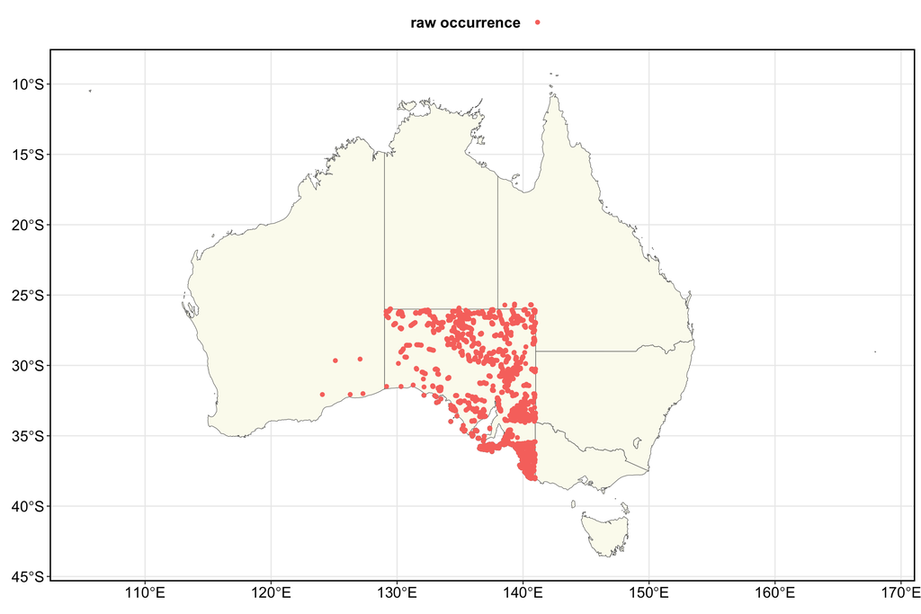

```r
#mapping
# Map
library(ozmaps)
aus <- ozmap_data(data = "states") # create a map layer with state boundaries
#visualise raw occurrence into a map
m1<- ggplot(sf_data) +
  stat_sf_coordinates()+
  geom_sf(data = aus, fill = "#FBFBEF")+
  geom_point(
    aes(geometry = geometry,color="",
        xmin = after_stat(x) - 0.1,
        xmax = after_stat(x) + 0.1,
        y = after_stat(y),
        height = 0.02),
    stat = "sf_coordinates"
  )+ labs(x = expression(""), colour = "raw occurrence", y = expression(""))+ theme_bw()

m1+ theme(axis.text.y = element_text(colour = "black", size = 14, face = "bold"),
          axis.text.x = element_text(colour = "black", face = "bold", size = 14),
          legend.text = element_text(size = 12, face ="bold", colour ="black"),
          legend.position = "top", axis.title.y = element_text(face = "bold", size = 14),
          axis.title.x = element_text(face = "bold", size = 14, colour = "black"),
          legend.title = element_text(size = 14, colour = "black", face = "bold"),
          panel.background = element_blank(), panel.border = element_rect(colour = "black", fill = NA, size = 1.2),
          legend.key=element_blank())
```

Now you can see that the raw occurrence mammal records from BDBSA dataset. Let us convert the mammal records using site as a factor, and then visualise on a map.

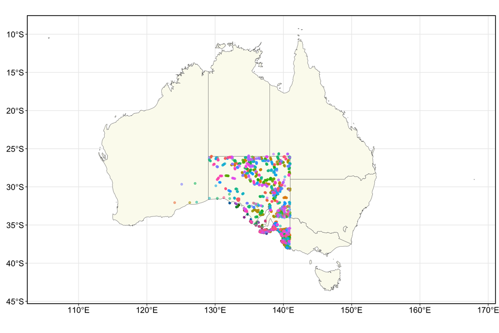

```r
# convert the site into a factor
sf_data$site<- as.factor(sf_data$site)
#visualise occurrence by Site on a map
m1<- ggplot(sf_data) +
  stat_sf_coordinates()+
  geom_sf(data = aus, fill = "#FBFBEF")+
  geom_point(
    aes(geometry = geometry,color=site,
        xmin = after_stat(x) - 0.1,
        xmax = after_stat(x) + 0.1,
        y = after_stat(y),
        height = 0.02, alpha=0.8),
    stat = "sf_coordinates"
  )+ labs(x = expression(""), colour = "site", y = expression(""))+ theme_bw()

m1+ theme(axis.text.y = element_text(colour = "black", size = 14, face = "bold"),
          axis.text.x = element_text(colour = "black", face = "bold", size = 14),
          legend.text = element_text(size = 12, face ="bold", colour ="black"),
          legend.position = "none", axis.title.y = element_text(face = "bold", size = 14),
          axis.title.x = element_text(face = "bold", size = 14, colour = "black"),
          legend.title = element_text(size = 14, colour = "black", face = "bold"),
          panel.background = element_blank(), panel.border = element_rect(colour = "black", fill = NA, size = 1.2),
          legend.key=element_blank())
```

# Summary

- In Summary one can extract species occurrence records of mammals from BDBSA using a GeoJson API query and
- plott the species occurrence records on a map using some simple code snippets as above.

We can create multiple faceted search query on TERN EcoPlots using the API and with some of the above steps extract information to suite your research questions.

# References

[TERN EcoPlots- Terrestrial Ecosystem Research Network.](https://ecoplots.tern.org.au/)

[The Biological Databases of South Australia (BDBSA)](https://www.environment.sa.gov.au/topics/science/information-and-data/biological-databases-of-south-australia)

[^1]: TERN, a.singhramesh@uq.edu.au